# ITPP - Lecture 5

A Practical Introduction to the Python Programming Language

# Homework

Homework 4 is due. Feedback for 2 and 3 are out.

```python
# Homework 4 help

todoList = [
    ['Walk the dog', 5],
    ['Do math homework', 9],
    ['Take a shower', 100],
    ['Do my Python hw', 200]
]

todoList.sort(key=lambda item: item[1])

# todoList.reverse()

counter = 0
# print(todoList)
print("Your todo list is:")
for todo in todoList:
#     print(todo)
    for field in todo:
        if counter % 2 == 0:
            print(field, end=", ")
        else:
            print("Priority: ", end="")
            print(field)
        counter = counter + 1
    print("\n")
```

```
Your todo list is:
Walk the dog, Priority: 5


Do math homework, Priority: 9


Take a shower, Priority: 100


Do my Python hw, Priority: 200
```

## Anonymous Lecture Discussion

http://app.chitchat.tech/

# Review

Last week we learned about:

- GitHub
- Lists
- Dictionaries
- Command Line
- Open Ended Project

- File Input and Output
- Using APIs with Requests
- Intro to Matplotlib

## File Input

Variables are a great way to store information. The problem with variables however is that the data does not **persist**. What happens when you store data into a variable but restart your program?

We can save our data to files on our system so later on we can access them. Let's open up the terminal and create a sample text file.

```
touch text-input.txt # creates a new file
echo "Hello World!" >> text-input.txt # adds the string to the text file
cat text-input.txt # displays the content of the text file
```

Now we'll be able to use the contents of that text file inside our program.

```python
greeting = open('./data.txt')
print(greeting.read())
greeting.close()
```

[output not shown]

`read()` allows us to read the all of the contents of a file into a single string. What if we wanted to separate the data?

Let's download this data file with stock data. Go back to your terminal and type in:

```
wget http://johnpham.net/cs190python/resources/NASDAQ100.csv
```

```python
data = open('./NASDAQ100.csv')
print(data.read())
```

```
1986-01-02,131.25,
1986-01-03,130.55,
1986-01-06,130.35,
1986-01-07,132.79,
1986-01-08,131.16,
1986-01-09,128.80,
1986-01-10,129.56,
1986-01-13,129.09,
1986-01-14,129.18,
1986-01-15,131.53,
1986-01-16,133.06,
1986-01-17,132.77,
1986-01-20,131.60,
1986-01-21,131.09,
1986-01-22,129.62,
1986-01-23,129.27,
1986-01-24,130.20,
1986-01-27,130.79,
1986-01-28,131.99,
1986-01-29,133.06,
1986-01-30,132.19,
1986-01-31,132.93,
1986-02-03,134.24,
1986-02-04,134.60,
1986-02-05,135.72,
1986-02-06,136.64,
1986-02-07,137.42,
1986-02-10,138.13,
1986-02-11,138.26,
1986-02-12,138.66,
1986-02-13,139.16,
1986-02-14,140.16,
1986-02-17,.,
1986-02-18,140.74,
1986-02-19,139.64,
1986-02-20,139.94,
1986-02-21,141.15,
1986-02-24,140.20,
1986-02-25,139.40,
1986-02-26,138.88,
```

[output cut: 8317 more lines]

```
2018-01-15,.,
2018-01-16,6737.14,
2018-01-17,6810.28,
2018-01-18,6811.38,
2018-01-19,6834.33,
2018-01-22,6906.28,
2018-01-23,6963.46,
2018-01-24,6919.35,
2018-01-25,6916.30,
2018-01-26,7022.97,
2018-01-29,6988.32,
2018-01-30,6930.73,
2018-01-31,6949.99,
2018-02-01,6901.50,
2018-02-02,6760.29,
```

There's a problem with the program above. It reads all of the data into 1 string. What if we wanted to separate it? Arrays are the perfect tool to do this.

```python
dataParsed = open('./NASDAQ100.csv')
# print(dataParsed.readlines()[0].split(","))
dataParsed = dataParsed.readlines()

for i in dataParsed:
    print(i.split(",")[1])

# dataParsed.close()
```

```
131.25
130.55
130.35
132.79
131.16
128.80
129.56
129.09
129.18
131.53
133.06
132.77
131.60
131.09
129.62
129.27
130.20
130.79
131.99
133.06
132.19
132.93
134.24
134.60
135.72
136.64
137.42
138.13
138.26
138.66
139.16
140.16
.
140.74
139.64
139.94
141.15
140.20
139.40
138.88
```

[output cut: 8317 more lines]

```
.
6737.14
6810.28
6811.38
6834.33
6906.28
6963.46
6919.35
6916.30
7022.97
6988.32
6930.73
6949.99
6901.50
6760.29
```

## File Output

File output lets us store the data that our program creates into files. Those files can then be used in our program later or in other programs.

```python
# (filename, mode)
outFile = open("file.txt", "w")
outFile.write("This is a filejkdfdfkjglsdkfghgkjdfgk I just made\n")
outFile.close()

inFile = open("file.txt")
print(inFile.read())
inFile.close()

# outFile = open("bobo.txt", "w")
# outFile.write("I'm feeling kind of hungry\n")
# outFile.close()

# inFile = open("bobo.txt")
# print(inFile.read())
# inFile.close()

# What happened to the first thing we wrote?
```

```
This is a filejkdfdfkjglsdkfghgkjdfgk I just made
```

## Using APIs with Requests

So far we've been downloading data through our terminal. That's an extra step that we don't need to do. We `requests`, we can download data directly from our program.

```python
import requests

rawData = requests.get('http://johnpham.net/cs190python/resources/NASDAQ100.csv')
print(rawData.text)

# This does not create a new file unlike before. The data is stored in your program's memory
```

```
1986-01-02,131.25,
1986-01-03,130.55,
1986-01-06,130.35,
1986-01-07,132.79,
1986-01-08,131.16,
1986-01-09,128.80,
1986-01-10,129.56,
1986-01-13,129.09,
1986-01-14,129.18,
1986-01-15,131.53,
1986-01-16,133.06,
1986-01-17,132.77,
1986-01-20,131.60,
1986-01-21,131.09,
1986-01-22,129.62,
1986-01-23,129.27,
1986-01-24,130.20,
1986-01-27,130.79,
1986-01-28,131.99,
1986-01-29,133.06,
1986-01-30,132.19,
1986-01-31,132.93,
1986-02-03,134.24,
1986-02-04,134.60,
1986-02-05,135.72,
1986-02-06,136.64,
1986-02-07,137.42,
1986-02-10,138.13,
1986-02-11,138.26,
1986-02-12,138.66,
1986-02-13,139.16,
1986-02-14,140.16,
1986-02-17,.,
1986-02-18,140.74,
1986-02-19,139.64,
1986-02-20,139.94,
1986-02-21,141.15,
1986-02-24,140.20,
1986-02-25,139.40,
1986-02-26,138.88,
```

[output cut: 8317 more lines]

```
2018-01-15,.,
2018-01-16,6737.14,
2018-01-17,6810.28,
2018-01-18,6811.38,
2018-01-19,6834.33,
2018-01-22,6906.28,
2018-01-23,6963.46,
2018-01-24,6919.35,
2018-01-25,6916.30,
2018-01-26,7022.97,
2018-01-29,6988.32,
2018-01-30,6930.73,
2018-01-31,6949.99,
2018-02-01,6901.50,
2018-02-02,6760.29,
```

If we wanted to, we can write the data to a file.

```python
import requests

rawData = requests.get('http://johnpham.net/cs190python/resources/NASDAQ100.csv')
print(rawData.text)

dataFile = open('rawNasdaqdata.txt', 'w')
dataFile.write('My data\n')
dataFile.write(rawData.text)
dataFile.close()

dataFile = open('rawNasdaqdata.txt')
print(dataFile.read())
dataFile.close()
```

```
1986-01-02,131.25,
1986-01-03,130.55,
1986-01-06,130.35,
1986-01-07,132.79,
1986-01-08,131.16,
1986-01-09,128.80,
1986-01-10,129.56,
1986-01-13,129.09,
1986-01-14,129.18,
1986-01-15,131.53,
1986-01-16,133.06,
1986-01-17,132.77,
1986-01-20,131.60,
1986-01-21,131.09,
1986-01-22,129.62,
1986-01-23,129.27,
1986-01-24,130.20,
1986-01-27,130.79,
1986-01-28,131.99,
1986-01-29,133.06,
1986-01-30,132.19,
1986-01-31,132.93,
1986-02-03,134.24,
1986-02-04,134.60,
1986-02-05,135.72,
1986-02-06,136.64,
1986-02-07,137.42,
1986-02-10,138.13,
1986-02-11,138.26,
1986-02-12,138.66,
1986-02-13,139.16,
1986-02-14,140.16,
1986-02-17,.,
1986-02-18,140.74,
1986-02-19,139.64,
1986-02-20,139.94,
1986-02-21,141.15,
1986-02-24,140.20,
1986-02-25,139.40,
1986-02-26,138.88,
```

[output cut: 16691 more lines]

```
2018-01-15,.,
2018-01-16,6737.14,
2018-01-17,6810.28,
2018-01-18,6811.38,
2018-01-19,6834.33,
2018-01-22,6906.28,
2018-01-23,6963.46,
2018-01-24,6919.35,
2018-01-25,6916.30,
2018-01-26,7022.97,
2018-01-29,6988.32,
2018-01-30,6930.73,
2018-01-31,6949.99,
2018-02-01,6901.50,
2018-02-02,6760.29,
```

## JSON

JSON is a way to organize data. It provides a uniform structure for us to work with.

```python
import requests
from IPython.core.display import display, HTML

gif = requests.get('https://api.giphy.com/v1/gifs/random?api_key=c6caa15f718f4a64859883c625d3d5ea&tag=&rating=G')

print(gif.json()['data']['image_original_url'])
imgURL = gif.json()['data']['image_original_url']
imgTag = "<img src='{}'/>".format(imgURL)
display(HTML(imgTag))
```

```
https://media1.giphy.com/media/xTk9ZBTF0hNOOLyKru/giphy.gif
```

[figure not shown]

## Introduction to Matplotlib

So we have all of this data. That's great and all but how can we get useful information out of it? Pictures are a great way to do so!

Let's graph the NASDAQ data.

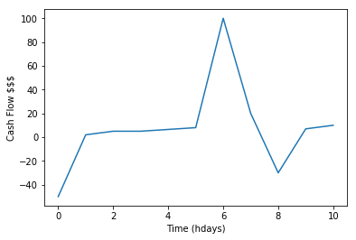

```python
# allows you to display charts within the notebook
%matplotlib inline

import matplotlib as mpl
import numpy as np
import matplotlib.pyplot as plt

bobo = [0, 1, 2, 3, 5, 6, 7, 8, 9, 10]
anna = [-50, 2, 5, 5, 8, 100, 20, -30, 7, 10]

plt.plot(bobo, anna)
plt.ylabel('Cash Flow $$$')
plt.xlabel('Time (hdays)')
plt.show()
```

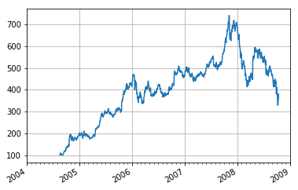

```python
import datetime
import numpy as np
import matplotlib.pyplot as plt
import matplotlib.dates as mdates
import matplotlib.cbook as cbook

years = mdates.YearLocator()   # every year
months = mdates.MonthLocator()  # every month
yearsFmt = mdates.DateFormatter('%Y')

# Load a numpy record array from yahoo csv data with fields date, open, close,
# volume, adj_close from the mpl-data/example directory. The record array
# stores the date as an np.datetime64 with a day unit ('D') in the date column.
with cbook.get_sample_data('goog.npz') as datafile:
    r = np.load(datafile)['price_data'].view(np.recarray)
# Matplotlib works better with datetime.datetime than np.datetime64, but the
# latter is more portable.
date = r.date.astype('O')

fig, ax = plt.subplots()
ax.plot(date, r.adj_close)


# format the ticks
ax.xaxis.set_major_locator(years)
ax.xaxis.set_major_formatter(yearsFmt)
ax.xaxis.set_minor_locator(months)

datemin = datetime.date(date.min().year, 1, 1)
datemax = datetime.date(date.max().year + 1, 1, 1)
ax.set_xlim(datemin, datemax)


# format the coords message box
def price(x):
    return '$%1.2f' % x
ax.format_xdata = mdates.DateFormatter('%Y-%m-%d')
ax.format_ydata = price
ax.grid(True)

# rotates and right aligns the x labels, and moves the bottom of the
# axes up to make room for them
fig.autofmt_xdate()

plt.show()
```

[figure not shown]

```python
# allows you to display charts within the notebook
%matplotlib inline

import matplotlib
import numpy as np
import matplotlib.pyplot as plt

dates = []
prices = []

data = open('NASDAQ100.csv').read().split(',')

# print(data)

counter = 0
for item in data:
    if counter % 2 == 0:
        dates.append(item)
    else:
        prices.append(item)
    counter += 1

dates.pop()
plt.plot(dates[:100], prices[:100], label='prices')
plt.show()
# print(len(dates), len(prices))
# print(dates)
```

# Homework 5

1. Create a new notebook naming it `[netid]_[homework5]`. An example of this is `jpham035_homework5`.
2. Create a Markdown cell with the following information:
   - A title
   - Your name
   - Your email
3. Create a program that manages allows many users to input their name and age. Once the users have signaled that they're done doing input, you will write the data to a text file.
4. Each person will also be randomly assigned a code name. You will be using this api: `http://names.drycodes.com/1?nameOptions=all` to get a random name.

```python
# Here's some code to get you started
import requests

curName = ''
curAge = 0
codeName = ''

while curName != 'q':
    curName = input("What is your name? ")
    print(curName)
    # how do you make a request to an API?
    # is the data in json?
```

[output not shown]

The file you output will be called `roster.txt` and will be formatted like this:

```
txt
1. name age codename
2. name age codename
3. name age codename
4. name age codename
```

The numbers preceeding the name and age tells us the order that the people typed in their info.